# WLE Dataset Classification

Sergio Gelves

Thursday, October 23, 2014

## Synopsis

Using the weight lifting exercise dataset from the following source http://groupware.les.inf.puc-rio.br/har a model is created to correctly classify the way Unilateral Dumbbell Biceps Curl was done. Class A is the correct way of doing the exercise all other classes are erroneous ways of doing the exercise.

## Loading data

First the data is downloaded from the internet and loaded into R.

```r
## download WLE training data file if it doesn't exist
if (!file.exists("./pml-training.csv")) {
    wleTrainingUrl = "https://d396qusza40orc.cloudfront.net/predmachlearn/pml-training.csv"
    download.file(url = wleTrainingUrl, destfile = "./pml-training.csv")

    ## remove link as it is no longer used
    rm(wleTrainingUrl)
}

## download WLE testing data file if it doesn't exist
if (!file.exists("./pml-testing.csv")) {
    wleTestingUrl = "https://d396qusza40orc.cloudfront.net/predmachlearn/pml-testing.csv"
    download.file(url = wleTestingUrl, destfile = "./pml-testing.csv")

    ## remove link as it is no longer used
    rm(wleTestingUrl)
}

## load data into R dataframes
pmlTraining = read.csv(file = "./pml-training.csv", na.strings=c("", "NA"))
pmlTesting = read.csv(file = "./pml-testing.csv", na.strings=c("", "NA"))
```

## Preprocessing

The first seven columns have to do with user and time so I exclude them. All columns with NAs are also excluded. This leaves us with 52 predictors and 1 Outcome column.

```r
## Remove first 7 columns as they are useless for the model
pmlTesting = pmlTesting[,-(1:7)]
pmlTraining = pmlTraining[,-(1:7)]

## Remove columns with NAs
cols=colSums(is.na(pmlTraining))==0
pmlTraining = pmlTraining[, cols]
pmlTesting = pmlTesting[, cols]
rm(cols)
```

Since the testing csv file doesn’t have the classes to actually test the data I divided the training csv file into 80% training and the other 20% for testing.

```r
## Load libraries
library(lattice)
library(ggplot2)
library(randomForest)
library(caret)

## Randomly separate data into a training and test set
set.seed(123)
inTrain = createDataPartition(pmlTraining$classe, p = 0.8, list = FALSE)
training = pmlTraining[inTrain, ]
testing = pmlTraining[-inTrain, ]
```

## A bit of data exploration

Just to see how some variables are distributed across classes

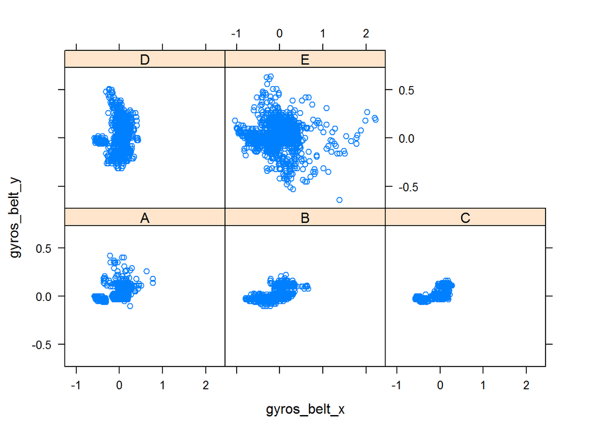

```r
xyplot(gyros_belt_y~gyros_belt_x | classe, pmlTraining)
```

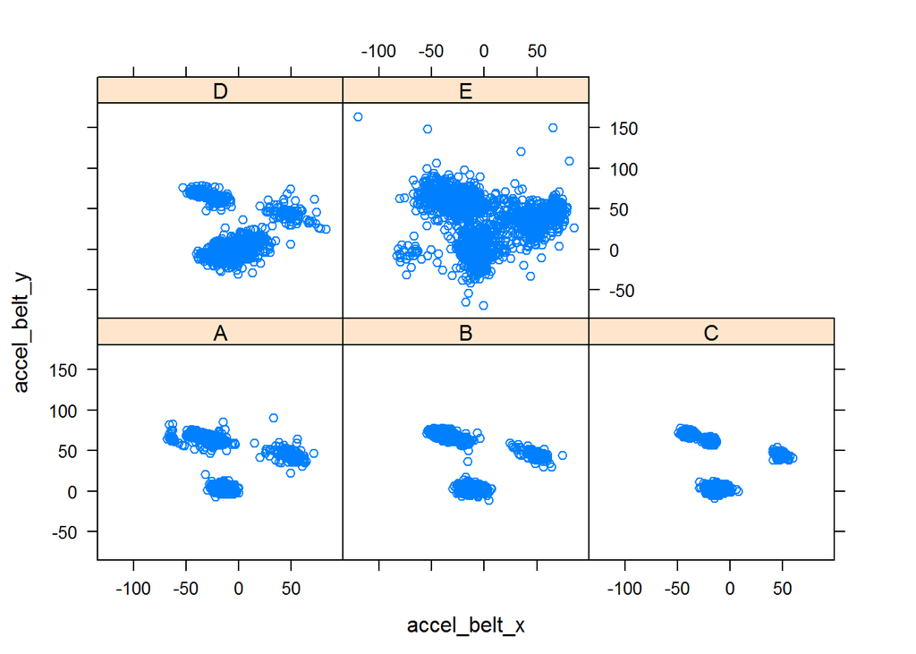

```r
xyplot(accel_belt_y~accel_belt_x | classe, pmlTraining)
```

## Model Training

Now the model is trained from the training data frame. Since this is a classification problem with several classes random forests seems appropriate for the job.

```r
## Train model (takes a while)
rfControl = trainControl(method="oob")
modFit = train(classe~., data=training, method="rf", trControl=rfControl, ntree=300)
modFit$finalModel
```

```
##
## Call:
##  randomForest(x = x, y = y, ntree = 300, mtry = param$mtry)
##                Type of random forest: classification
##                      Number of trees: 300
## No. of variables tried at each split: 27
##
##         OOB estimate of  error rate: 0.57%
## Confusion matrix:
##      A    B    C    D    E class.error
## A 4459    3    1    0    1 0.001120072
## B   20 3014    3    1    0 0.007899934
## C    0   13 2717    8    0 0.007669832
## D    0    1   25 2546    1 0.010493587
## E    0    2    4    7 2873 0.004504505
```

Now we see the confusion matrix with the testing values.

```r
pred = predict(modFit, testing)
table(pred, testing$classe)
```

```
##
## pred    A    B    C    D    E
##    A 1115    8    0    0    0
##    B    1  749    2    0    0
##    C    0    2  680    6    0
##    D    0    0    2  636    1
##    E    0    0    0    1  720
```